# Movie Nights through History

## Setup

```r
knitr::opts_chunk$set(message=FALSE, warning=FALSE)
library(tidyverse)
library(lubridate)
library(nnet)
theme_set(theme_bw())
setwd('~/Projects/Personal/MovieNight/')
```

### Import Data

The script that pulls all previous weeks’ voting results is here and comes courtesy of @gnomon.

I import each file, merge them together into a single data frame, and write it back to disk.

```r
weeks = list.files(path = 'old_data', pattern = 'week', full.names = TRUE)
movies = list.files(path = 'old_data', pattern = 'movies', full.names = TRUE)
movie_df = read.csv(movies[1], row.names = 1, header = FALSE)
movie_df
titles = movie_df[[1]]
names(titles) = rownames(movie_df)
titles
weeks[1]
substr(weeks[1], 10, 19)
vote_df = read.csv(weeks[1], check.names = FALSE)
vote_df
vote_df = (vote_df
           %>% gather(TitleLong, Vote, -Timestamp)
           %>% count(TitleLong, Vote, name = 'Count')
           %>% mutate(Week = substr(weeks[1], 10, 19),
                      Title = titles[TitleLong]))
vote_df

for (week in weeks[2:length(weeks)]){
    movie = gsub('week','movies',week)
    movie_df = read.csv(movie, row.names = 1, header = FALSE)
    titles = movie_df[[1]]
    names(titles) = rownames(movie_df)
    vote_df = rbind(vote_df,
                    (read.csv(week, check.names = FALSE)
                     %>% gather(TitleLong, Vote, -Timestamp)
                     %>% count(TitleLong, Vote, name = 'Count')
                     %>% mutate(Week = substr(week, 10, 19),
                                Title = titles[TitleLong])))
}

head(vote_df)
tail(vote_df)
vote_df = (vote_df
           %>% spread(Vote, Count, fill = 0)
           %>% gather(Vote, Count, starts_with('I')))
head(vote_df)
write.csv(vote_df, file = 'all_weeks.csv', row.names = TRUE)
```

Once the data have been merged, I open them in OpenRefine to clean up any instances of the same movie being given slightly different names on different weeks. The JSON file with the OpenRefine commands is here.

Then I read in the cleaned data:

```r
all_dat = read.csv('all-weeks-cleaned.csv')
head(all_dat)
all_dat = select(all_dat, -Column)
levels(factor(all_dat$Vote))
all_dat = (all_dat
           %>% mutate(Week = ymd(Week),
                      Vote = factor(Vote,
                                    labels = c('meh', 'Nope', 'Yes please!')),
                      Vote = factor(Vote, levels = c('Yes please!', 'meh', 'Nope'))))
```

## Naive Visualization

Without filtering out any themed weeks, holidays, weeks when there was an error in the poll, etc., here are some plots:

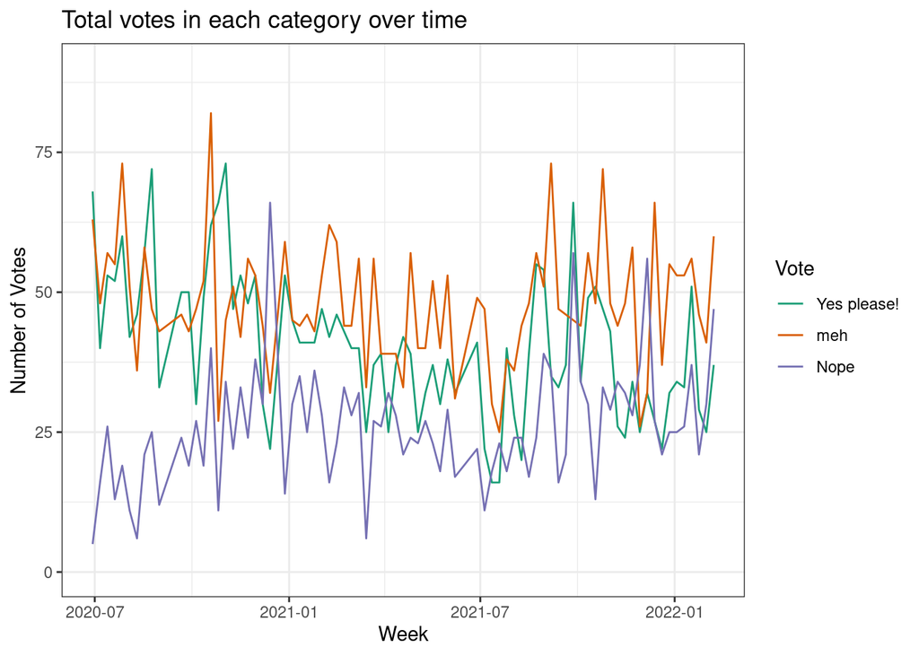

```r
cat_totals = (all_dat
              %>% group_by(Week, Vote)
              %>% summarize(Count = sum(Count)))
cat_plt = ggplot(cat_totals, aes(Week, Count, colour = Vote)) +
    geom_line() +
    scale_colour_brewer(palette = 'Dark2') +
    ylim(0, 90) +
    ylab('Number of Votes') +
    ggtitle('Total votes in each category over time')
cat_plt
```

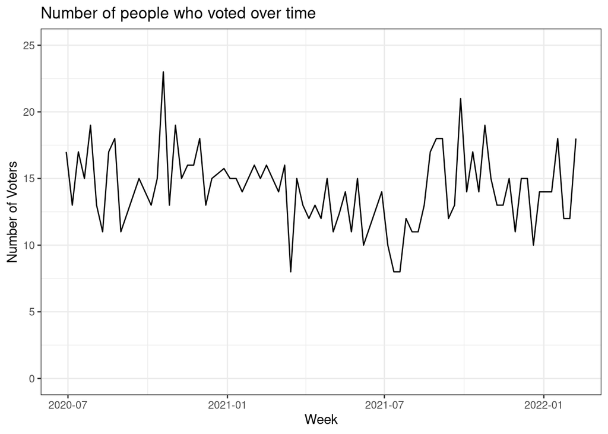

```r
tots = (cat_totals
        %>% group_by(Week)
    %>% summarize(Count = sum(Count)/8))
tot_plt = ggplot(tots, aes(Week, Count)) +
    geom_line() +
    ylim(0,25) +
    ylab('Number of Voters') +
    ggtitle('Number of people who voted over time')
tot_plt
```

These are both pretty noisy. I’m seeing that the number of negative votes was lower in the beginning, climbed over the first few months that we used this system, and has stabilized pretty well. The number of voters each week is harder to make sense of through the noise. Some moving-window averaging will probably help clarify that.

```r
cat_prop = (cat_totals
           %>% group_by(Week)
           %>% mutate(CountProp = Count/sum(Count),
                      Total = sum(Count)/8)
           %>% ungroup())
head(cat_prop)
```

```
## # A tibble: 6 x 5
##   Week       Vote        Count CountProp Total
##   <date>     <fct>       <int>     <dbl> <dbl>
## 1 2020-06-29 Yes please!    68    0.5       17
## 2 2020-06-29 meh            63    0.463     17
## 3 2020-06-29 Nope            5    0.0368    17
## 4 2020-07-06 Yes please!    40    0.385     13
## 5 2020-07-06 meh            48    0.462     13
## 6 2020-07-06 Nope           16    0.154     13
```

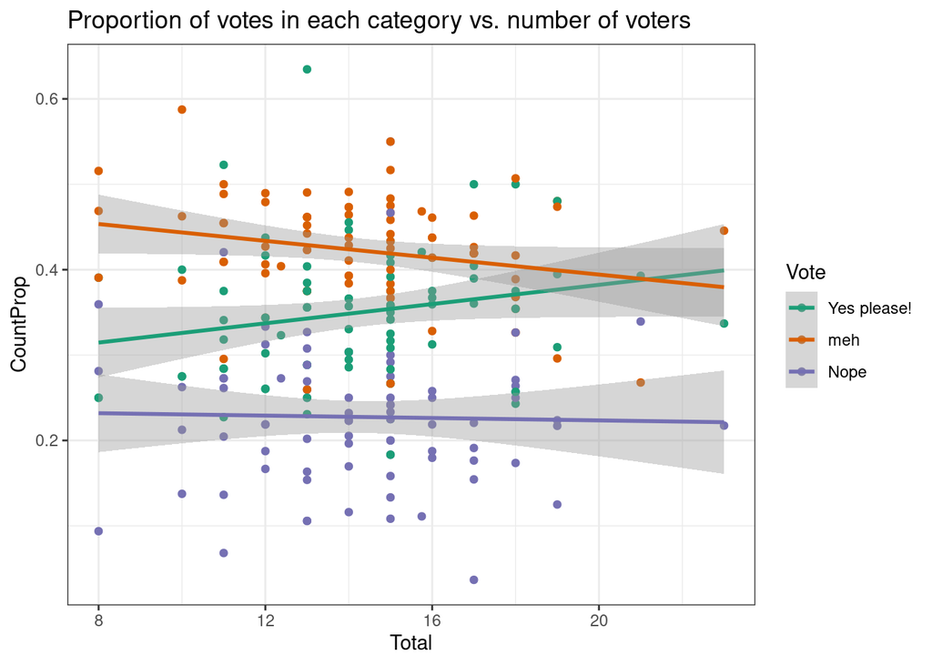

```r
cat_prop_plt = ggplot(cat_prop, aes(Total, CountProp, colour = Vote)) +
    geom_point() +
    geom_smooth(method = 'lm') +
    scale_colour_brewer(palette = 'Dark2') +
    ggtitle('Proportion of votes in each category vs. number of voters')
cat_prop_plt
```

## What should we watch next

### Most Frequent Candidates

Of the movies that have not won, these have been on the list the most frequently.

```r
# head(all_dat)

winners = read.csv('winners.csv')
# head(winners)

freqs = (all_dat
  %>% filter(!(Title %in% winners$Winner))
  %>% count(Title)
  %>% mutate(Count = n/3)
  %>% arrange(desc(n), desc(Title))
  %>% select(-n))
freqs %>% filter(Count >= 5)
```

```
##                   Title Count
## 1  WhoFramedRogerRabbit    11
## 2              TurboKid     8
## 3        MyCousinVinnie     6
## 4              Clueless     6
## 5              WarGames     5
## 6                 Venom     5
## 7               Tremors     5
## 8           Terminator2     5
## 9        MinorityReport     5
## 10              Matilda     5
## 11               FAQaTT     5
## 12            Dodgeball     5
```

I have also manually curated a list of the movies most in keeping with our 80’s/90’s computer nerd roots:

- batteries not included
- war games
- burn after reading
- robocop
- spy kids
- turbo kid
- terminator 2
- the net
- tracer

### Runners Up

```r
get_second = function(v){
  r = rank(-1*v)
  return(which(r == 2))
}

seconds = (all_dat
 %>% filter(SpecialWeek == '')
 %>% spread(Vote,Count)
 %>% mutate(Score = `Yes please!` - Nope)
 %>% group_by(Week)
 %>% summarize(Second = Title[get_second(Score)])
 %>% filter(!(Second %in% winners$Winner)))

(seconds
  %>% count(Second)
  %>% arrange(desc(n)))
```

```
## # A tibble: 26 x 3
## # Groups:   Week [24]
##    Week       Second                 n
##    <date>     <chr>              <int>
##  1 2020-07-06 BatmanAndRobin         1
##  2 2020-07-13 MyCousinVinnie         1
##  3 2020-08-10 BurnAfterReading       1
##  4 2020-08-10 ShesTheMan             1
##  5 2020-08-17 Blade                  1
##  6 2020-09-21 FAQaTT                 1
##  7 2020-10-19 AddamsFamilyValues     1
##  8 2020-11-02 FirstWivesClub         1
##  9 2020-11-30 Matilda                1
## 10 2021-01-04 Venom                  1
## # … with 16 more rows
```

Once previous winners are excluded, no movie came in second more than once

Here are the movies that came in second, sorted by how frequently they occurred in lists at all.

```r
sec_freq = left_join(seconds, freqs, by = c('Second' = 'Title'))
sec_freq %>% arrange(desc(Count), desc(Second))
```

```
## # A tibble: 26 x 3
## # Groups:   Week [24]
##    Week       Second                 Count
##    <date>     <chr>                  <dbl>
##  1 2020-07-13 MyCousinVinnie             6
##  2 2021-05-10 WarGames                   5
##  3 2021-01-04 Venom                      5
##  4 2021-04-12 MinorityReport             5
##  5 2020-11-30 Matilda                    5
##  6 2020-09-21 FAQaTT                     5
##  7 2021-10-11 TheKitchen                 4
##  8 2021-08-23 SuicideSquad               4
##  9 2021-10-04 NightAtTheMuseum           4
## 10 2021-02-08 HuntForTheWilderpeople     4
## # … with 16 more rows
```

### Movies with lots of positive votes

```r
mv_prop = (all_dat
           %>% filter(SpecialWeek == '',
                      !(Title %in% winners$Winner))
           %>% select(-SpecialWeek, -ExtraRow)
           %>% group_by(Week, Title)
           %>% mutate(CountProp = Count/sum(Count))
           %>% ungroup()
           %>% group_by(Title, Vote)
           %>% summarize(MeanProp = mean(CountProp))
           %>% ungroup())

head(mv_prop)
```

```
## # A tibble: 6 x 3
##   Title                   Vote        MeanProp
##   <chr>                   <fct>          <dbl>
## 1 AddamsFamilyValues      Yes please!    0.428
## 2 AddamsFamilyValues      meh            0.380
## 3 AddamsFamilyValues      Nope           0.192
## 4 AdventuresInBabysitting Yes please!    0.294
## 5 AdventuresInBabysitting meh            0.588
## 6 AdventuresInBabysitting Nope           0.118
```

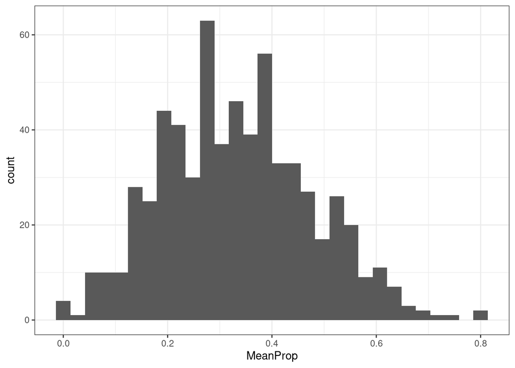

```r
ggplot(mv_prop, aes(x = MeanProp)) +
  geom_histogram()
```

Let’s pull out the top 10%

```r
yes_prop = filter(mv_prop, Vote == 'Yes please!')
quantile(yes_prop$MeanProp, 0.9)
```

```
##       90%
## 0.4173526
```

10% of non-winner movies received 41% or more of their votes in the positive category (averaged over all the times they appeared on the poll)

```r
yes_prop %>% filter(MeanProp >= 0.417) %>% arrange(desc(MeanProp)) %>% data.frame()
```

```
##                 Title        Vote  MeanProp
## 1    BurnAfterReading Yes please! 0.6363636
## 2               Blade Yes please! 0.6307190
## 3      BatmanAndRobin Yes please! 0.6153846
## 4            JohnWick Yes please! 0.6111111
## 5             TheHeat Yes please! 0.5714286
## 6          ShesTheMan Yes please! 0.5695187
## 7    BedknobsAndBroom Yes please! 0.5333333
## 8           BlingRing Yes please! 0.5210084
## 9                Repo Yes please! 0.5000000
## 10     FirstWivesClub Yes please! 0.4994152
## 11           Clueless Yes please! 0.4950587
## 12         TheFounder Yes please! 0.4903570
## 13   LeagueOfTheirOwn Yes please! 0.4809524
## 14              Fargo Yes please! 0.4545455
## 15             StepUp Yes please! 0.4545455
## 16        OceansEight Yes please! 0.4423077
## 17              Josie Yes please! 0.4375000
## 18        TheOldGuard Yes please! 0.4375000
## 19     PracticalMagic Yes please! 0.4289855
## 20       PartyMonster Yes please! 0.4285714
## 21 AddamsFamilyValues Yes please! 0.4279176
## 22    DeathBecomesHer Yes please! 0.4173913
## 23     FastAndFurious Yes please! 0.4170040
```

The above are the 23 movies that have received the most positive votes without winning

## To Do

- Further clean the data to tease out theme/holiday/error weeks vs. everything else
- Multinomial regression of proportion votes/cat vs. # voters
- Suggestions are welcome via the [issues tab](https://github.com/JCSzamosi/MovieNight/issues), but may be ignored.

```r
head(all_dat)
```

```
##                                      TitleLong       Week       Title
## 1 Votes [Babe 2: Pig in the City (1998, 1:36)] 2020-06-29       Babe2
## 2 Votes [Babe 2: Pig in the City (1998, 1:36)] 2020-06-29       Babe2
## 3 Votes [Babe 2: Pig in the City (1998, 1:36)] 2020-06-29       Babe2
## 4             Votes [Beetlejuice (1988, 1:32)] 2020-06-29 Beetlejuice
## 5             Votes [Beetlejuice (1988, 1:32)] 2020-06-29 Beetlejuice
## 6             Votes [Beetlejuice (1988, 1:32)] 2020-06-29 Beetlejuice
##          Vote Count SpecialWeek ExtraRow
## 1         meh     9
## 2        Nope     3
## 3 Yes please!     5
## 4         meh    12
## 5        Nope     0
## 6 Yes please!     5
```

```r
mult_dat = (cat_totals
            %>% select(Week, Vote, Count)
            %>% spread(Vote, Count)
            %>% rename(no = Nope,
                       yes = `Yes please!`)
            %>% select(Week, no, meh, yes))
mult_dat
```

```
## # A tibble: 80 x 4
## # Groups:   Week [80]
##    Week          no   meh   yes
##    <date>     <int> <int> <int>
##  1 2020-06-29     5    63    68
##  2 2020-07-06    16    48    40
##  3 2020-07-13    26    57    53
##  4 2020-07-20    13    55    52
##  5 2020-07-27    19    73    60
##  6 2020-08-03    11    51    42
##  7 2020-08-10     6    36    46
##  8 2020-08-17    21    58    57
##  9 2020-08-24    25    47    72
## 10 2020-08-31    12    43    33
## # … with 70 more rows
```

```r
mult_resp = as.matrix(mult_dat[,2:4])
mult_resp
```

```
##       no meh yes
##  [1,]  5  63  68
##  [2,] 16  48  40
##  [3,] 26  57  53
##  [4,] 13  55  52
##  [5,] 19  73  60
##  [6,] 11  51  42
##  [7,]  6  36  46
##  [8,] 21  58  57
##  [9,] 25  47  72
## [10,] 12  43  33
## [11,] 24  46  50
## [12,] 19  43  50
## [13,] 27  47  30
## [14,] 19  52  49
```

[output cut: 66 more lines]

```r
head(mult_resp)
```

```
##      no meh yes
## [1,]  5  63  68
## [2,] 16  48  40
## [3,] 26  57  53
## [4,] 13  55  52
## [5,] 19  73  60
## [6,] 11  51  42
```

```r
voters = rowSums(mult_resp)
voters = scale(voters)
week = mult_dat$Week
week = scale(week)
mod = multinom(mult_resp ~ voters*week)
summary(mod)
```

```
## Call:
## multinom(formula = mult_resp ~ voters * week)
##
## Coefficients:
##     (Intercept)       voters       week  voters:week
## meh   0.6292731 -0.050096248 -0.1425550 -0.007657113
## yes   0.4417702  0.003172356 -0.2856748  0.036055799
##
## Std. Errors:
##     (Intercept)     voters       week voters:week
## meh  0.02839008 0.02782298 0.02942458  0.02825156
## yes  0.02941192 0.02877935 0.03059520  0.02914462
##
## Residual Deviance: 19439.15
## AIC: 19455.15
```

```r
exp(coef(mod))
```

```
##     (Intercept)    voters      week voters:week
## meh    1.876246 0.9511379 0.8671398   0.9923721
## yes    1.555458 1.0031774 0.7515070   1.0367137
```

```r
pred = head(round(fitted(mod), 2))
head(pred)
```

```
##     no  meh  yes
## 1 0.17 0.40 0.42
## 2 0.17 0.40 0.43
## 3 0.18 0.41 0.42
## 4 0.17 0.41 0.42
## 5 0.18 0.41 0.41
## 6 0.17 0.41 0.42
```